# Homework 7

DATS 6101 · Fall 2026

Sam Nicholes

2026-11-24

```r
# 272 eruptions of Old Faithful: eruption length and wait to the next (minutes).
geyser_data <- faithful

# Lengths, in miles, of 141 major North American rivers (a vector).
river_miles <- rivers

# 1,000 earthquakes near Fiji, magnitude 4.0 and up, with the number of
# stations that reported each one.
quake_data <- quakes

# Ten patients, two sleeping drugs each: extra hours of sleep.
sleep_data <- sleep

# The spread ratio: residual SD in the top third of fitted values
# over the bottom third. Near 1 means the spread is even.
spread_ratio <- function(m) {
  third <- cut(fitted(m), quantile(fitted(m), 0:3 / 3), include.lowest = TRUE)
  s <- tapply(resid(m), third, sd)
  s[[3]] / s[[1]]
}
# ~ 1: the spread is even across predictions
# > 1: residuals fan out as predictions grow, the classic funnel.
# < 1: residuals shrink as predictions grow.
```

# Part 1 · One eruption, or the average eruption (14 points)

## (1a) The two intervals at 4 minutes

```r
geyser <- lm(waiting ~ eruptions, data = faithful)

# predict wait time for eruption = 4 minutes
geyser_erupt_4 <- data.frame(eruptions = 4)
geyser_wait <- predict(geyser, newdata = geyser_erupt_4)

geyser_ci <- predict(geyser, newdata = geyser_erupt_4, interval = "confidence")
# CI - interval to capture the true average value at confidence
geyser_pi <- predict(geyser, newdata = geyser_erupt_4, interval = "prediction")
# PI - interval to capture the predicted value at confidence. Wider than CI because of added residual variance
```

Predicted wait time for an eruption that lasted 4 minutes: 76.393

95% CI for wait time: 75.619, 77.167. This interval will capture the true average wait time for a 4 minute eruption 95% of the time.

95% PI for wait time: 64.724, 88.062. This interval will capture the predicted wait time for a 4 minute eruption 95% of the time.

## (1b) Checking them against the eruptions near 4 minutes

```r
geyser_data_4 <- subset(faithful, eruptions >= 3.8 & eruptions <= 4.2)
geyser_count_4 <- nrow(geyser_data_4) # How many

# wait times in respective intervals?
in_ci <- geyser_data_4$waiting >= geyser_ci[, "lwr"] & geyser_data_4$waiting <= geyser_ci[, "upr"]
in_pi <- geyser_data_4$waiting >= geyser_pi[, "lwr"] & geyser_data_4$waiting <= geyser_pi[, "upr"]

# share inside each interval
geyser_share_ci <- mean(in_ci)
geyser_share_pi <- mean(in_pi)
```

Count of eruptions lasting about 4 minutes: 48

Share of wait times that fall within the CI: 0.125

Share of wait times that fall within the PI: 0.917

## (1c) Which interval answers the visitor

The Prediction Interval answers the visitor’s question. It describes the range of predicted values based on observed eruption times. The Confidence Interval is meant to describe the interval that could capture the average wait time of a 4 minute eruption. In part b, it shows which wait times fall in the interval meant to capture the average value, the Confidence Interval.

# Part 2 · A median with no formula (16 points)

## (a) Mean, median and histogram

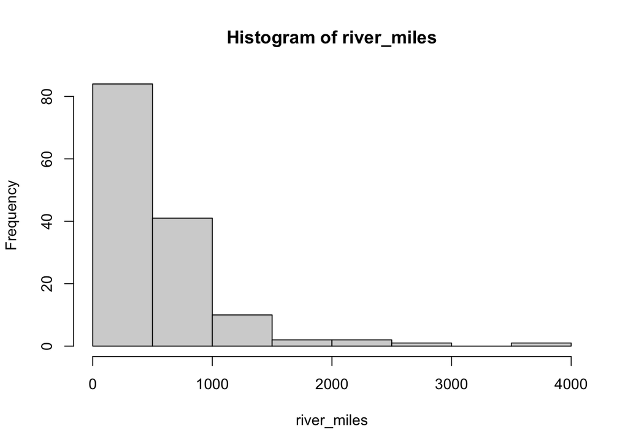

```r
mean_river <- mean(river_miles)
median_river <- median(river_miles)

hist(river_miles)
```

The mean is: 591.184

The median is: 425

The mean and median are far apart because of the right skew in the data - the rivers that several thousand miles long.

## (b) Bootstrapping the mean and the median

## (c) Why the medians are lumpy

# Part 3 · The longest river (12 points)

## (a) Bootstrapping the maximum

## (b) The probability of resampling the maximum

## (c) What the interval can and cannot say

# Part 4 · A slope when the spread fans out (16 points)

## (a) The formula’s slope, and the residuals

## (b) Bootstrapping the slope

## (c) Which standard error, and what the bootstrap cannot fix

# Part 5 · Ten patients, twice (16 points)

## (a) Shuffling all 20 labels

## (b) Flipping signs within patients

# Part 6 · Bootstrap or permutation, and the report (16 points)

## (a) An interval for the difference

## (b) Three sentences for a report

## (c) Two sentences that are wrong

# AI disclosure

## Critique

*150-300 words. Either name something the assistant got wrong and what it would have cost, or show the prompts you used trying to break it when it held up. Both earn full marks.*